# General migration advise

#### Different Scripts

If your target country uses a different script than your home country for documents (Latin script, Arabic script, Cyrillic script, Greek script, Devanagari script, etc.), then you will have an extra layer of bureaucratic difficulty.

The most safe but expensive way to deal with this is to have official translations (maybe with an Apostille), see which conventions they use to transcribe/transliterate things like your name or the name of your university, and continue using them everywhere.

- For example, from [this Wikipedia entry](https://en.wikipedia.org/wiki/Romanization_of_Greek), the common name “Γιάννης” can be written as Yannis, Jani, Ioannis, Yianis, or Giannis, but not Giannes.
- For example, the Russian naming convention includes a patronymic inside full names, and also uses the Cyrillic script!

As I said, you have to figure out the name you’ll use abroad.

[figure not shown]

# Information Labyrinths

Government information is convoluted:

> Get ready to read everything at least three times.

It will not make any sense by the first read. You’ll be confused by the bureaucratic gibberish, the unhelpful forum posts, and the broken links. Little by little, you’ll start to see how everything connects.

This is harder if you’re going to a place that speaks another language. Even the most international-friendly countries have their websites with tons of links for information only available in the local language.

The most helpful method is to find someone who has already done what you did and wants to help, or to look for information online (like this blog!)

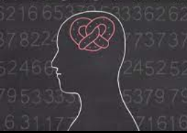

# Money talks

When talking about money we need to be serious.

Learn how to make an international transaction from your home country. Go to you bank and ask them for all the necessary paperwork. However, don’t hesitate to ask around many banks and see which has a better deal for international transactions.

For example, in my country, very few banks work with Euros easily, so I had to search for one where I could at least save them without converting them into another currency.

Also, look for good places to exchange currency! In my experience banks tend to have the worst possible deals! I prefer currency exchange houses, one can ask around many of them to get a good deal. Virtual currency exchanges and using crypto are getting popular, but I’ve not used them yet.

> Closing all you bank accounts when leaving is a bad idea

They are useful for sending money back, and paying for local bureaucracy easily. So leave one or two accounts you can use.

How will your taxes work once you stop living in your home country? Is there anything you need to do to avoid being taxed? This information is important, and varies from place to place. For example, most countries don’t tax their citizens once they are residents abroad, yet one of the big exceptions is the USA.

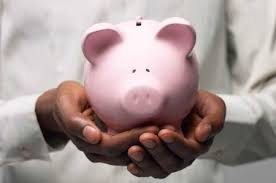

# Navigation apps

To get around, Google Maps is very trustworthy. It even lets you download maps for offline use!

For public transport, I’ve found Moovit to be very well done. Instead of downloading a local app for each city you go to, Moovit has a decent summary of most cities.

[figure not shown]

# Miscellaneous

Find out the **address format** (for houses, mail, etc) of the place you’re going to.

Check **electricity specifications**, like plug shape, voltage and frequency, to know if you’ll need to buy adapters or transformers. Extensions are a good idea.

> Safe travels!